# Mountain treelines climb slowly despite rapid climate warming - Lu - 2021 - Global Ecology and Biogeography - Wiley Online Library

[Global Ecology and Biogeography](https://onlinelibrary.wiley.com/journal/14668238)

[Volume 30, Issue 1](https://onlinelibrary.wiley.com/toc/14668238/2021/30/1) p. 305-315

[figure not shown]

META‐ANALYSIS

Full Access

# Mountain treelines climb slowly despite rapid climate warming

[Xiaoming Lu](https://onlinelibrary.wiley.com/action/doSearch?ContribAuthorStored=Lu%2C+Xiaoming)

[Eryuan Liang](https://onlinelibrary.wiley.com/action/doSearch?ContribAuthorStored=Liang%2C+Eryuan)

[Yafeng Wang](https://onlinelibrary.wiley.com/action/doSearch?ContribAuthorStored=Wang%2C+Yafeng)

[Flurin Babst](https://onlinelibrary.wiley.com/action/doSearch?ContribAuthorStored=Babst%2C+Flurin)

[J. Julio Camarero](https://onlinelibrary.wiley.com/action/doSearch?ContribAuthorStored=Camarero%2C+J+Julio)

First published: 13 November 2020

https://doi.org/10.1111/geb.13214

## Abstract

### Aim

To better understand how climate change drives altitudinal treeline dynamics at large spatial scales.

### Location

Northern Hemisphere.

### Time period

1901–2018.

### Major taxa studied

Tree species that constitute alpine treelines.

### Methods

We conducted a meta‐analysis of annual treeline shift rates at 143 sites from 38 published studies. For each site, we calculated current change rates in annual or seasonal temperatures, precipitation and drought (standardized precipitation evapotranspiration index). We then evaluated relationships between treeline shift rates, and site characteristics and climate using standard and partial correlation analyses, as well as generalized linear models. These analyses were conducted at the hemispheric scale and for two geographic subsets of subarctic (north of 60° N) and temperate regions (south of 60° N).

### Results

Treelines ascended at 88.8%, remained stable at 10.5% and descended at 0.7% of the sites. The mean hemispheric shift rate (0.354 m/year) was half of what would be expected from climate warming alone. Treeline shifts were significantly faster in subarctic than temperate regions. The precipitation effect was more important than temperature for predicting treeline shift rate. In the subarctic regions, autumn precipitation mostly determined treeline shift rates. In the temperate region, warmer temperatures and higher autumn precipitation accelerated shift rates, whereas wetter springs reduced them. Autumn precipitation and winter mean minimum temperature best explained the treeline shift rates across the Northern Hemisphere.

### Main conclusions

A combination of thermal and hydrological factors drives treeline shift rates across the Northern Hemisphere, with precipitation assuming an important modifying role of the general temperature‐driven treeline ascent. Regional treeline shift rates, therefore, co‐depend on drying and wetting trends, which should be considered in future estimates of global change impacts on alpine ecosystems.

## 1 INTRODUCTION

As multiple lines of evidence are demonstrating, global climate change is re‐shaping the distribution of many terrestrial organisms and ecosystems, including forests (Bhatta et al., 2018; Büntgen et al., 2015; Chen et al., 2011; Dial et al., 2016; Hagedorn et al., 2019; Lenoir et al., 2008). Cold biomes such as alpine treelines are thus regarded as relevant ecological indicators of climate change impacts on terrestrial ecosystems. This is, in part, because the tree cohorts that form the treeline are often sensitive to recent temperature rises (Carrer & Urbinati, 2006; Holtmeier & Broll, 2007; Peñuelas et al., 2007). Accordingly, alpine treelines have shown an upward shift during the last century that was likely related to warming (Camarero & Gutiérrez, 2004; Case & Duncan, 2014; Elliott & Petruccelli, 2018; Harsch et al., 2009; Liang et al., 2016). Treeline shifts can have both positive or negative feedbacks on mountain biomes by affecting local and regional climate, soil carbon storage, nutrient cycling, hydrological processes and biodiversity (Greenwood & Jump, 2014; Hartley et al., 2012; Holtmeier & Broll, 2007; Wilmking et al., 2006). Thus, the sign and rate of treeline shifts, as well as their climatic drivers, need to be well understood and quantified.

Among the potential drivers of current and future alpine treeline shifts, climate warming is generally assumed to be the most important and ubiquitous factor. Globally, alpine treeline positions are associated with a growing season soil temperature of 6.7 °C (Körner & Paulsen, 2004). However, climate warming alone cannot explain the observed range shifts of alpine plant species on European mountains (Grytnes et al., 2014). In addition to the global temperature effects, other regional to local climate factors, such as moisture availability (Daniels & Veblen, 2004; Elliott et al., 2020; Sigdel et al., 2018), winter snow cover (Kirdyanov et al., 2012) and wind damage (Holtmeier & Broll, 2007; Payette, 2007) have been shown to co‐determine the treeline position. For example, drought affects alpine treeline dynamics in the Himalayas (Liang et al., 2014). In this massive range where the highest treelines in the Northern Hemisphere are located, the upward shift of the treeline has been stronger in the wetter eastern compared to the drier western part. This suggests that moisture availability mediates the treeline ascent rate (Sigdel et al., 2018). Altitudinal treelines are, therefore, sensitive to different climatic drivers depending on regional climate regimes. However, a consensus about which climate factors ultimately determine treeline shift rates at hemispheric to global scales is still lacking.

An earlier meta‐analysis of global treeline responses to climate concluded that strong winter warming promoted an upward shift of treelines (Harsch et al., 2009). Moreover, this study showed that diffuse treelines, characterized by a gradual decrease in tree density and height with elevation, were particularly sensitive to the temperature increase as compared with abrupt treelines that show a sharp decrease in tree density and height (Harsch et al., 2009). A recent study further highlighted the importance of precipitation in driving the shift of subarctic forest‐tundra ecotones (Rees et al., 2020). These results indicated that treeline shift rates and their climatic drivers may differ between subarctic and other ecoregions in the Northern Hemisphere. However, the scope of these earlier assessments was limited because they mainly considered a binary treeline response (i.e., no ascent versus ascent). Therefore, a quantitative study is needed to assess how the actual rate of treeline shifts responds to climate.

The objective of this study was to investigate the dominant climate factors driving alpine treeline shift rates across the Northern Hemisphere. To reach this goal, altitudinal treeline shift rates for the period 1901–2018 were estimated from a set of 143 existing study sites distributed across the Northern Hemisphere. This network was further divided into two sub‐regions to assess potential regional differences in treeline shift rates and their climatic drivers. Due to low solar angles and varied topography, most mountain treelines in subarctic regions contain characteristics of both alpine and latitudinal treelines (Danby & Hik, 2007). Moreover, most of the available treeline shift studies are located close to or beyond 60° N in the subarctic region (Rees et al., 2020). Hence, we chose 60° N as the threshold between the temperate and subarctic sub‐regions. To minimize potential biases from non‐climatic drivers, we ensured that there were no large disturbances such as fire and logging in the surroundings of the selected treeline sites. Inspired by a growing body of literature suggesting that water availability and demand limit trees even towards their uppermost distribution edge (Biondi, 2001; Rees et al., 2020; Sigdel et al., 2018), we tested the hypothesis that precipitation mediates the sensitivity of treeline shift rates to climate warming at hemispheric scales.

## 2 METHODS

### 2.1 Data collection

This study focused on Northern Hemisphere mountains to assess altitudinal treeline shifts, because most recent treeline studies (91%) have been carried out there, whilst few (9%, cf. Harsch et al., 2009) have been done in the Southern Hemisphere. We only included in our meta‐analysis the original data that clearly stated treeline position (defined as the elevation reached by trees of at least 2 m height), krummholz treeline (shrubby, multi‐stemmed individuals) or forest altitudinal limits (defined as the elevation with a tree crown closure of at least 25%). To maximize the extent of our dataset, references providing exact treeline shift rates recorded in their results and discussion sections were also included. By contrast, studies of tree species lines, latitudinal treelines and purely qualitative estimations of treeline shifts were excluded. Further, treeline shift studies reporting recent local disturbances (logging or fires; e.g., Van Bogaert et al., 2011) were also excluded, because we looked for undisturbed treelines that mainly respond to changes in climate conditions. In total, 143 sites from 38 studies were finally retained from articles and reports published during the period of 1986–2020 (Figure 1; a list of the data sources is found in the Appendix; Supporting Information Table S1). The latitudinal range of these treeline sites is 12.07°–70.85° N. The ground vegetation at 89 alpine treeline sites is dominated by shrubs or dwarf shrubs, whereas the vegetation at or above the remaining sites is unknown. Some studies (16 sites) reconstructed treeline position using remote sensing data, maps, and repeated photographs, whereas most of them (127 sites) reconstructed treeline shifts using dendrochronology. Both of these methods have advantages and disadvantages. The first method may accurately describe treeline position, but isolated trees may not be distinguishable in old images (e.g., Camarero & Gutiérrez, 2004). The second method has a longer time span (usually 50–200 years), but it is based on dating tree establishment of surviving trees and cannot capture trees that recruited in the past but then died and disappeared prior to sampling (Johnson et al., 1994). The two methods were combined in a few studies to calculate the treeline shift rates (e.g., Shiryaev et al., 2019).

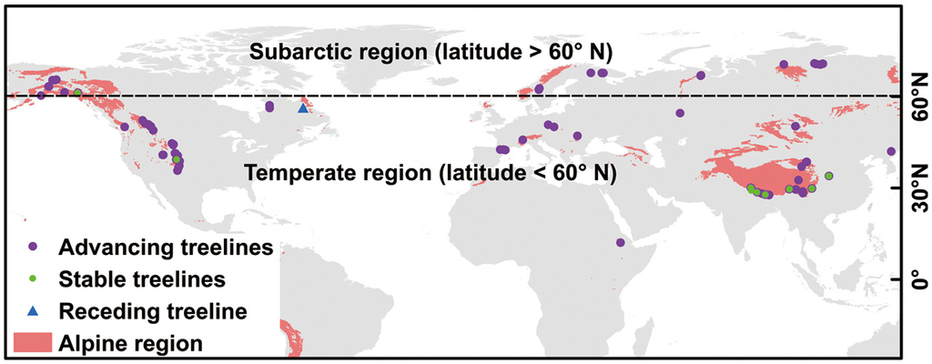

**FIGURE 1**

Locations of the studied 143 treeline sites in the Northern Hemisphere. Subarctic and temperate regions indicate the areas with latitude above and below 60° N in the Northern Hemisphere, respectively. Purple dots, green dots and blue triangle are sites showing advancing, stable and receding treelines, respectively. Red patches correspond to alpine areas according to Testolin et al. (2020) [Colour figure can be viewed at [wileyonlinelibrary.com](https://www.wileyonlinelibrary.com/)]

We recorded the general information of each treeline site (e.g., treeline form: diffuse, abrupt or krummholz; tree species; study site; coordinates; elevation; study period and elevational shift rate). Diffuse treelines show a gradual decrease in tree density and height upwards, whereas abrupt treelines show sharp changes in tree density or height. Krummholz treelines are dominated by shrubby, multi‐stemmed individuals (Harsch et al., 2009). When some information (e.g., treeline form) was not reported in the original research, we managed to collect or estimate them from other references on nearby sites published by the same authors. When the treeline shift data were not available in digital form, a plot digitizer program (http://plotdigitizer.sourceforge.net) was used to extract the data from the figures published in the references. If the study recorded the mean and maximum treeline shift rates, only mean shift rate was recorded to ensure that the data were comparable across sites (e.g., Kullman & Öberg, 2009). The study period was assumed as the duration between the start and end years of the treeline shift process recorded in each publication. If the study period began prior to 1900, the treeline shift rate since 1901 was calculated. Annual rates of treeline shift (m/year) were estimated by dividing the absolute elevational shift value by the elapsed period (see Camarero & Gutiérrez, 2004).

Climate data were obtained for the period 1901–2018 from the Climate Research Unit dataset (Harris et al., 2014; CRU TS4.0–4.04) gridded at 0.5° resolution using the Climate Explorer webpage (http://climexp.knmi.nl/). Monthly climate data from the geographically closest grid cell to the coordinates of the 143 study sites were downloaded. The used climate parameters included: mean temperature (T), mean maximum temperature (MT), mean minimum temperature (NT), total precipitation (Pr), and the standardized precipitation evapotranspiration index (SPEI). The SPEI is a drought index proposed by Vicente‐Serrano et al. (2010) that considered the contributions of temperature, potential evapotranspiration and precipitation on drought. Negative SPEI values indicate dry conditions. Mean (T, MT, NT, SPEI) or summed (Pr) values of climate data were then calculated for the year (January to December) and the following seasons: spring, March to May; summer, June to August; autumn, September to November; winter, previous December to February.

We note that the 0.5° spatial resolution of the CRU dataset can result in a relatively coarse representation of the absolute treeline site climate. However, as our statistical analyses focused mostly on inter‐annual variability (and not on absolute climate), we could reasonably assume that the climatic variability from the CRU grid cells is consistent with the variability experienced by our study treeline sites. The rates of change in annual and seasonal climate were calculated using ordinary linear least squares regressions. Corresponding to the treeline shift rate (m/year) at each site, the mean annual change rate in annual and seasonal climate variables was computed by dividing the observed change by the length of the study period (e.g., mm/year for Pr).

The subarctic region constitutes one of the most important bioclimatic zones with significant treeline dynamics. A recent subarctic treeline study mainly focused on the treeline sites located close to (> 57° N) or beyond 60° N (*c*. 93%, Rees et al., 2020). Mountain treelines in subarctic regions contained both alpine and arctic treelines (Danby & Hik, 2007). There are relatively few alpine treelines between 50°–60° N (Körner, 1998). Only one of the retained treeline sites is located at *c*. 12° N, whereas all other sites are situated beyond 27° N. To enable comparisons of our findings with those from Rees et al. (2020), we divided our hemispheric dataset into two sub‐regions (subarctic region, north of 60° N and temperate region, south of 60° N) for regional scale analyses and inter‐comparisons.

### 2.2 Data analysis

The difference between the treeline shift rates in subarctic and temperate regions was tested using Student’s *t* test. Regular and partial Pearson correlations (two‐tailed) were used to test which variables were significantly (*p* < .05) related to the treeline shift rate for subarctic and temperate regions, and also for the Northern Hemisphere. These variables included: site latitude, longitude, elevation, and the climate variables (e.g., SpringT is the annual rate of mean spring temperature).

The partial correlation between the annual treeline shift rate and latitude was calculated by holding the effects of longitude and elevation constant. For the effect of seasonal temperatures on treeline shift rates, partial correlations were calculated by controlling for latitude, longitude, elevation and annual rates of precipitation for the same season. Partial correlations between the annual treeline shift rate and SPEI were calculated by controlling for the effects of latitude, longitude and elevation.

Lastly, we used generalized linear models (GLMs, McCullagh & Nelder, 1989) to determine which combination of explanatory variables best explained the annual treeline shift rate for the aforementioned three regions. GLMs are extensions of multiple linear regressions with independent observations (McCullagh & Nelder, 1989). In the first step, GLMs were performed using site characteristics and climate factors that significantly affected the treeline shift rates. Combinations of different factors were also input into each GLM for analysis. Subsequently, the Akaike information criterion (AIC) was used to identify the most parsimonious model. The best model was selected as the one with the highest explanatory power (*r*<sup>2</sup>) and fewest explanatory variables, in case the difference in AIC values between the best and other competing models was less than 2 (Burnham & Anderson, 2002). These analyses were performed using the ‘*Hmisc*’ and ‘*ggm*’ packages (Harrell, 2014; Sadeghi & Marchetti, 2012) in the R statistical environment (R Development Core Team, 2017).

## 3 RESULTS

### 3.1 Treeline shift rates and climate variation

The mean hemispheric treeline shift rate was 0.354 m/year. Since 1901, treelines have shifted upwards at 127 out of the 143 sites (*c*. 88.8%; Figure 1; Supporting Information Table S1), remained stable at 15 sites (*c*. 10.5%) and descended at 1 site (*c*. 0.7%). In subarctic regions (latitude > 60° N), there was an upward treeline shift at 27 sites and 1 site showed a stable treeline. In temperate regions (latitude < 60° N), upward shifts occurred at 100 sites and only 1 site showed a receding treeline. Notably, treeline shift rates in subarctic (mean of 0.476 m/year) were significantly higher than those in temperate regions (mean of 0.324 m/year; Figure 2, Student’s *t* test, *p* = .02).

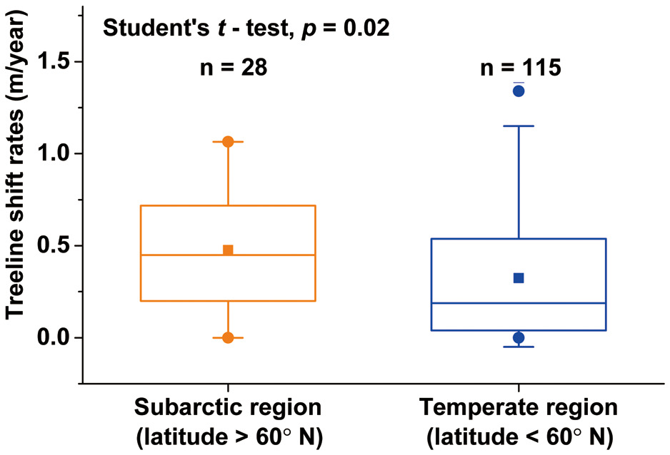

**FIGURE 2**

Box‐plot showing the alpine treeline shift rates in subarctic (latitude > 60° N) and temperate regions (latitude < 60° N). Boxes indicate the median and 25th and 75th percentiles, while the error bars on the upper and lower sides correspond to the maximum and minimum whisker values, respectively. The rectangular dots in the boxes are mean values of treeline shift rates in these two regions and circular dots on the upper and lower sides of the boxes show the 99% and 1% values, respectively. Numbers of the studied treeline sites are shown above each box [Colour figure can be viewed at [wileyonlinelibrary.com](https://www.wileyonlinelibrary.com/)]

In parallel, seasonal and annual temperatures have increased at most of the study sites (Supporting Information Table S1). Winter warming was thereby most prevalent with mean rates across all sites greater than +0.01 °C/year, followed by positive trends in spring, annual, summer and autumn temperatures. Spring precipitation increased at 105 out of 143 sites, with a mean value of +0.105 mm/year. By contrast, summer and autumn precipitations decreased with mean rates of −0.13 and −0.009 mm/year, respectively. Winter precipitation increased with a mean rate of +0.042 mm/year. Annual mean precipitation of all sites also increased by +0.01 mm/year. For the SPEI, we found that it has decreased during winter (i.e., towards drier conditions) at 87 sites, whereas it has increased for all other seasons (i.e., towards wetter conditions) at more than half of the study sites.

We found that the mean change rates of temperatures and precipitation (except autumn temperatures and summer precipitation) were higher in subarctic than temperate regions (Supporting Information Table S1). In addition, mean SPEI in subarctic and temperate regions showed increasing and decreasing trends, respectively. As indicated by temperature and SPEI, more than half of treeline sites in subarctic regions have experienced a warming and wetting trend since 1901, whereas temperate regions were characterized by warming and drying trends in more than half of the sites (except spring SPEI).

### 3.2 Factors limiting treeline shift rates

At the hemispheric scale, the treeline shift rates showed significant (*p* < .05) positive correlations with latitude, annual mean, mean maximum and mean minimum temperatures, mean minimum winter temperature, autumn and annual precipitations, and winter SPEI (Figure 3a). We also found a significant negative correlation between the treeline shift rates and elevation that, however, turned into a significantly positive relationship when calculating the partial correlation and controlling for the effects of site latitude and longitude. Autumn precipitation rate was the most important climate factor positively related to the treeline shift rates (Figure 4).

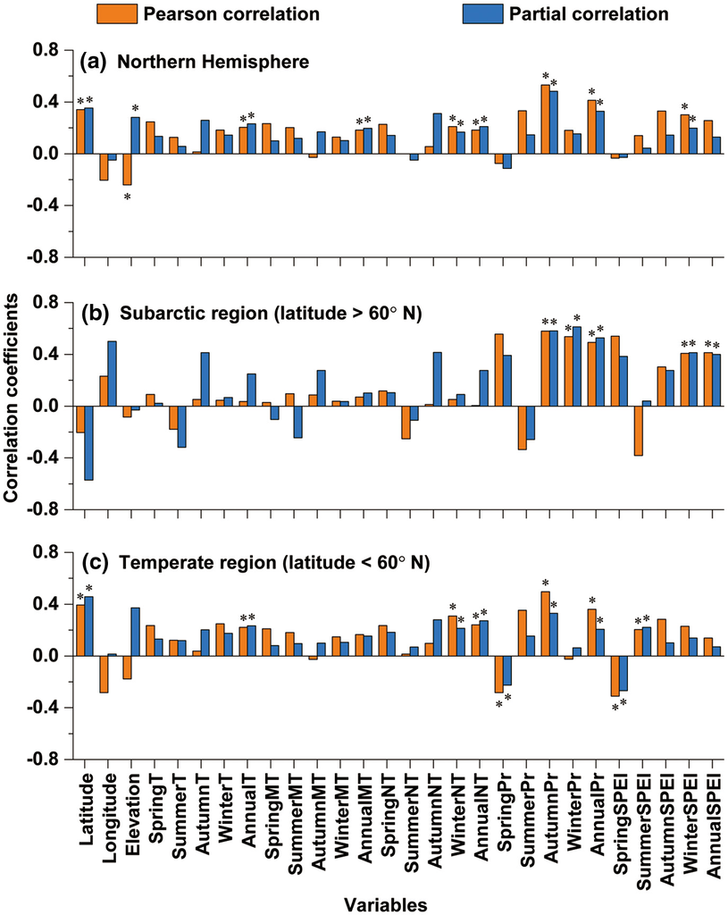

**FIGURE 3**

Pearson and partial correlation coefficients calculated between the annual treeline shift rate and site information and the rates of annual or seasonal climate variables for Northern Hemisphere (a), subarctic (latitude > 60° N, b) and temperate regions (latitude < 60° N, c). Site information and climate factors with both of the Pearson and partial correlation analyses indicating significant positive or negative correlation coefficients (*p* < .05) are indicated by asterisks. Abbreviations: T = mean temperature; MT = mean maximum temperature; NT = mean minimum temperature; Pr = precipitation; SPEI = standardized precipitation evapotranspiration index [Colour figure can be viewed at [wileyonlinelibrary.com](https://www.wileyonlinelibrary.com/)]

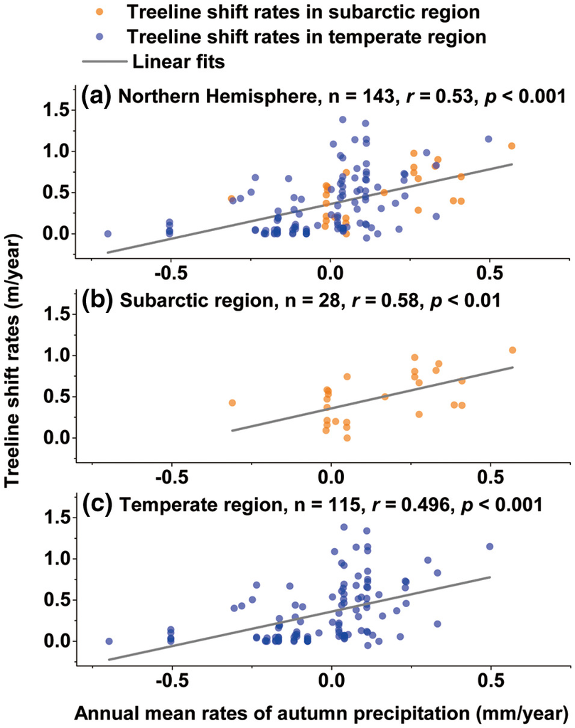

**FIGURE 4**

Linear regressions between annual mean rates of autumn precipitation and the treeline shift rates in the Northern Hemisphere (a), the subarctic (latitude > 60° N, b), and the temperate regions (latitude < 60° N, c) [Colour figure can be viewed at [wileyonlinelibrary.com](https://www.wileyonlinelibrary.com/)]

In subarctic regions, the treeline shift rates were significantly associated with autumn, winter and annual precipitation changes (Figure 3b). In temperate regions, significant positive correlations were observed between treeline shift rates and latitude, and also with the rates of annual mean and mean minimum temperatures, winter mean minimum temperature, autumn and annual precipitation, as well as summer SPEI (Figure 3c). By contrast, shift rates were significantly negatively correlated with spring precipitation and SPEI rates in temperate regions.

GLMs showed that a combination of winter mean minimum temperature and autumn precipitation best predicted the treeline shift rate in the Northern Hemisphere (*r*<sup>2</sup> = .319, Table 1; Supporting Information Table S2). Importantly, these two climate variables were not correlated (*r* = .03, *p* = .71). Autumn precipitation rate better explained the treeline shift rates in subarctic regions (*r*<sup>2</sup> = .337). In temperate regions, the GLM with annual mean minimum temperature rate, as well as spring and autumn precipitation rates, was selected to explain the treeline shift rate (Table 1). These three climate variables together explained 31.4% of the shift rate variability.

TABLE 1. Results of the best‐fitted generalized linear models (GLMs) calculated for the Northern Hemisphere, subarctic (latitude > 60° N) and temperate regions (latitude < 60° N)

| Regions | Variables |  |  | *r* <sup>2</sup> | AIC<sub>best</sub> |
| --- | --- | --- | --- | --- | --- |
| Northern Hemisphere | WinterNT** | AutumnPr*** |  | .319 | 53.761 |
| Subarctic region | AutumnPr** |  |  | .337 | 3.934 |
| Temperate region | AnnualNT* | AutumnPr*** | −SpringPr* | .314 | 51.744 |

### Note

- Abbreviations: NT = mean minimum temperature; Pr = precipitation; AIC<sub>best</sub> = Akaike information criterion of the most parsimonious model. The positive and negative effects are indicated with plus and minus signs, respectively. The significance of the variables in ANOVA procedures is indicated by asterisks (‘*’, ‘**’ and ‘***’ indicate .01 < *p* < .05, .001 < *p* < .01 and *p* < .001, respectively).

## 4 DISCUSSION

Altitudinal treelines are easily recognizable boundaries separating subalpine and alpine plant communities in mountain ranges. Hence, their dynamics epitomize the impacts of climate change on terrestrial ecosystems, calling for a better understanding of the underlying drivers and processes. Our study advances this understanding by demonstrating that a combination of temperature and precipitation effects has influenced treeline dynamics across the Northern Hemisphere since the early 20th century. Importantly, both air temperature and precipitation played substantial roles as drivers of treeline shift. Site‐level characteristics, such as elevation, may induce precipitation changes further affecting treeline dynamics.

In line with a previous meta‐analysis (Harsch et al., 2009), our quantitative analysis showed that most alpine treelines have shifted upwards throughout the past century. However, the mean treeline shift rate was low (0.354 m/year). It was approximately three times lower than a previous estimate of global range shifts of multiple taxa (1.1 m/year; Chen et al., 2011). Our calculated rate was also lower than another quantitative estimate of global average range shift for more than 1,700 plant and animal species (0.61 m/year; Parmesan & Yohe, 2003). These two global studies on the redistribution of species showed temporal patterns that matched the rates of climate warming (Chen et al., 2011; Parmesan & Yohe, 2003). Our findings, by contrast, document a rate of annual summer mean temperature at treeline in +0.005 °C/year. Assuming a temperature lapse rate of *c*. −0.0056 °C/m with increased elevation in mountain regions (Rolland, 2003), our results provide evidence that the mean treeline shift rate was more than twice lower than could generally be expected (0.89 m/year) as a function of the rise in mean temperatures.

Based on the publications that underlie our meta‐analysis, shrub species dominated the vegetation above the treelines at more than 60% of sites (89 sites). As shown by some studies, interactions between neighbouring trees and site‐level characteristics significantly influence treeline dynamics, for instance by controlling the regeneration niche of trees (Elliott, 2011; Malanson et al., 2019; Sigdel et al., 2020). Such local site effects, together with possible natural or anthropogenic disturbances that may not have been fully excluded from our analyses, may partly explain why climate variables only accounted for 31.9% of the variance in treeline shifts in the Northern Hemisphere. More work is thus needed to investigate the contribution of species interactions and site‐level characteristics when attempting to forecast treeline shifts (Liang et al., 2016).

Higher treeline shift rates in subarctic than in temperate regions may be linked to different climatic drivers and their variation trends (Figures 2 and 3). In the subarctic, the treeline advance was prevalent, likely due to climate warming (Harsch et al., 2009; Körner & Paulsen, 2004). However, we found that treeline shift rates were mainly limited by autumn precipitation in the subarctic (Figure 3), which is in line with the results of a recent study on subarctic treelines (Rees et al., 2020). In addition to the positive effect of autumn precipitation rate, treeline shift rates in temperate regions also showed significant positive and negative correlations with changing rates of annual temperatures and spring precipitation, respectively. Notably, the mean rates in precipitation were largely opposite between these two regions (i.e., increase in subarctic versus decrease in temperate regions; see Supporting Information Table S1), leading to dampened shift rates in temperate regions. We hypothesize that warming and wetting trends could further accelerate treeline advances in the subarctic in the future, whereas the treeline shifts in temperate areas may slow down or even reverse as climate becomes warmer and drier.

Among the assessed climate factors, low winter temperature is one of the key drivers of treeline shifts in the Northern Hemisphere. This is in line with Harsch et al. (2009), who reported that treeline advances corresponded to strong winter warming. In fact, an increase in winter mean minimum temperatures was observed at 137 out of 143 study sites (Supporting Information Table S1). Warmer winter‐season temperatures could potentially reduce plant damage due to snow and wind abrasion (Harsch et al., 2009), and thus have positive effects on survival rates of both trees and their recruits (Kullman & Öberg, 2009). Alpine treeline ascents depend on the successful recruitment and establishment of young trees, rather than on the enhanced growth of established trees (Holtmeier & Broll, 2007). Accordingly, high survival rates of tree seedlings and saplings after the winter season are a prerequisite for substantial treeline shifts (Camarero & Gutiérrez, 2004).

Precipitation is recognized as a crucial climate factor driving distribution range shifts of organisms at continental, regional and local scales (Siepielski et al., 2017). Moisture limitation has already been observed at several drought‐prone treelines (Biondi, 2001; Elliott et al., 2020; Liang et al., 2014). Warmer growing season temperature and sufficient moisture benefit the seedling emergence and growth at alpine treelines (Körner & Paulsen, 2004; Lett & Dorrepaal, 2018). Wet autumn conditions could lead to later soil freezes and enhance upward treeline shifts by facilitating long‐term seedling survival (Gill et al., 2015; Savage et al., 2013). Moreover, precipitation from late autumn to winter can fall as snowfall and shelter seedlings from harsh climate conditions, such as winter desiccation and early spring frost damage, by providing a more favourable microclimate (Batllori et al. 2009; Lett & Dorrepaal, 2018). Moderate snow depth may also provide sufficient water for tree growth and seedling survival at the beginning of the growth season (Hättenschwiler & Smith, 1999). In our study, snow increased (precipitation during winter and spring) at more than half of the sites (Supporting Information Table S1). Increased spring snowfall may have negative effects on tree growth through a delayed snowmelt and thus a later onset of cambial activity in temperate regions. This effect can uncouple growth phenology from air temperatures (Vaganov et al., 1999). In addition, a too thick snowpack can prevent tree establishment and wet snow conditions in early spring increase the risk of fungal infections to the seedlings (Holtmeier & Broll, 2007; Tomback & Resler, 2007).

Our findings emphasize that the response of treeline shift rate to climate warming strongly depends on local precipitation and temperature–precipitation interactions outside the Circum Arctic region (Table 1; Supporting Information Table S2). As climate warming progresses, it may induce drought stress or lead to shallow and discontinuous snow cover at drier treelines and thus limits tree growth and recruitment (e.g., Elliott et al., 2020; Kueppers et al., 2017; Moyes et al., 2015). Such responses of tree recruitment and growth to climate have been observed at alpine treelines in the Rocky Mountains (Elliott, 2012; Elliott et al., 2020), Sierra Nevada (Lloyd & Graumlich, 1997), central Himalayas (Sigdel et al., 2018), and the Spanish Pyrenees (Galván et al., 2015). In recent decades, water shortage has enhanced the synchrony of tree growth across Eurasian regions including treeline sites, and tree growth has become more limited by water demand almost worldwide (Babst et al., 2019; Jiang et al., 2019; Shestakova et al., 2019; Zhang et al., 2015). Tree recruitment at alpine treelines has also shown gradual declines at some drought‐prone sites (Camarero & Gutiérrez, 2004). In fact, the warming and drying trend (indicated by SPEI) in temperate regions (Supporting Information Table S1) suggests that variations in annual or seasonal precipitation have not compensated for the temperature‐induced increase in evaporative demand. Therefore, precipitation and soil moisture are likely to become more important drivers of treeline dynamics in a future warmer world, particularly for temperate regions.

In summary, we have provided a first quantitative synthesis of treeline shift rates for the Northern Hemisphere. We found that the shift rates were mainly positive since ascents were detected at 88.8% of the study sites, but slow treeline shift rates were observed despite rapid climate warming. Treeline shifts in subarctic sites were faster than in temperate regions depending on regional climate trends. Both temperature and precipitation were related to treeline shift rates in the Northern Hemisphere since 1901, supporting synergistic effects of climate warming and antagonistic effects of wetting/drying on treeline dynamics. Increasing precipitation promoted treeline ascents in the subarctic, whereas increasing water limitation dampened this process in the temperate regions. Looking forward, divergent treeline shifts may occur in the future as a function of different climate trends in subarctic and temperate regions. To further advance our understanding of treeline dynamics and forest redistributions, we encourage future empirical and modelling studies not only to consider, but to quantify the interactive effects between climate warming, precipitation changes, and biotic (e.g., competition or facilitation) factors, as well as the ecohydrological processes that affect treeline dynamics. To quantify the effects of species interactions upon treeline shifts, international cooperation of treeline plot network groups is needed to carry out more detailed field surveys to monitor the vegetation information at and above the alpine treeline ecotones.

## ACKNOWLEDGMENTS

This research is funded by the National Natural Science Foundation of China (41525001, 42030508), the Strategic Priority Research Program of the Chinese Academy of Sciences (XDA20050101), the Second Tibetan Plateau Scientific Expedition and Research Program (STEP) (2019QZKK0301) and F.B. acknowledges statutory funds from the W. Szafer Institute of Botany, Polish Academy of Sciences (PAS), as well as support from the project “Inside out” (#POIR.04.04.00‐00‐5F85/18‐00) funded by the HOMING programme of the Foundation for Polish Science co‐financed by the European Union under the European Regional Development Fund.

## AUTHOR CONTRIBUTIONS

E.L., J.J.C. and X.L. designed the research; X.L., J.J.C., F.B. and Y.W. collected and analysed data; and all authors edited and contributed to discussing and writing the paper.

## APPENDIX 1: DATA SOURCES

Aakala, T., Hari, P., Dengel, S., Newberry, S. L., Mizunuma, T., & Grace, J. (2014). A prominent stepwise advance of the tree line in north‐east Finland. *Journal of Ecology*, *102*(6), 1582–1591. [https://doi.org/10.1111/1365‐2745.12308](https://doi.org/10.1111/1365-2745.12308)

Bekker, M. F. (2005). Positive feedback between tree establishment and patterns of subalpine forest advancement, Glacier National Park, Montana, USA. *Arctic Antarctic and Alpine Research*, *37*(1), 97–107. https://doi.org/10.1657/1523‐0430(2005)037[0097:Pfbtea]2.0.Co;2

Camarero, J. J., & Gutiérrez, E. (2004). Pace and pattern of recent treeline dynamics: Response of ecotones to climatic variability in the Spanish Pyrenees. *Climatic Change*, *63*(1–2), 181–200. https://doi.org/10.1023/B:Clim.0000018507.71343.46

Carrara, P. E., & McGeehin, J. P. (2015). Evidence of a higher late‐Holocene treeline along the Continental Divide in central Colorado. *The Holocene*, *25*(11), 1829–1837. https://doi.org/10.1177/0959683615591353

Danby, R. K., & Hik, D. S. (2007). Variability, contingency and rapid change in recent subarctic alpine tree line dynamics. *Journal of Ecology*, *95*(2), 352–363. [https://doi.org/10.1111/j.1365‐2745.2006.01200.x](https://doi.org/10.1111/j.1365-2745.2006.01200.x)

Dang, H., Zhang, Y., Zhang, Y., Zhang, K., & Zhang, Q. (2015). Variability and rapid response of subalpine fir (*Abies fargesii*) to climate warming at upper altitudinal limits in north‐central China. *Trees*, *29*(3), 785–795. [https://doi.org/10.1007/s00468‐015‐1156‐9](https://doi.org/10.1007/s00468-015-1156-9)

Davis, E. L., Brown, R., Daniels, L., Kavanagh, T., & Gedalof, Z. (2020). Regional variability in the response of alpine treelines to climate change. *Climatic Change*, *162*(3), 1365–1384. [https://doi.org/10.1007/s10584‐020‐02743‐0](https://doi.org/10.1007/s10584-020-02743-0)

Devi, N. M., Kukarskih, V. V., Galimova, A. A., Mazepa, V. S., & Grigoriev, A. A. (2020). Climate change evidence in tree growth and stand productivity at the upper treeline ecotone in the Polar Ural Mountains. *Forest Ecosystems*, *7*, 7. [https://doi.org/10.1186/s40663‐020‐0216‐9](https://doi.org/10.1186/s40663-020-0216-9)

Devi, N., Hagedorn, F., Moiseev, P., Bugmann, H., Shiyatov, S., Mazepa, V., & Rigling, A. (2008). Expanding forests and changing growth forms of Siberian larch at the Polar Urals treeline during the 20th century. *Global Change Biology*, *14*(7), 1581–1591. [https://doi.org/10.1111/j.1365‐2486.2008.01583.x](https://doi.org/10.1111/j.1365-2486.2008.01583.x)

Dial, R. J., Berg, E. E., Timm, K., McMahon, A., & Geck, J. (2007). Changes in the alpine forest‐tundra ecotone commensurate with recent warming in southcentral Alaska: Evidence from orthophotos and field plots. *Journal of Geophysical Research‐Biogeosciences*, *112*(G4), G04015. https://doi.org/10.1029/2007JG000453

Du, H., Liu, J., Li, M., Büntgen, U., Yang, Y., Wang, L., Wu, Z., & He, H. (2018). Warming‐induced upward migration of the alpine treeline in the Changbai Mountains, northeast China. *Global Change Biology*, *24*(3), 1256–1266. https://doi.org/10.1111/gcb.13963

Elliott, G. P., & Cowell, C. M. (2015). Slope aspect mediates fine‐scale tree establishment patterns at upper treeline during wet and dry periods of the 20th century. *Arctic Antarctic and Alpine Research*, *47*(4), 681–692. [https://doi.org/10.1657/Aaar0014‐025](https://doi.org/10.1657/Aaar0014-025)

Gamache, I., & Payette, S. (2005). Latitudinal response of subarctic tree lines to recent climate change in eastern Canada. *Journal of Biogeography*, *32*(5), 849–862. [https://doi.org/10.1111/j.1365‐2699.2004.01182.x](https://doi.org/10.1111/j.1365-2699.2004.01182.x)

He, Z., Zhao, W., Zhang, L., & Liu, H. (2013). Response of tree recruitment to climatic variability in the alpine treeline ecotone of the Qilian Mountains, Northwestern China. *Forest Science*, *59*(1), 118–126. [https://doi.org/10.5849/forsci.11‐044](https://doi.org/10.5849/forsci.11-044)

Jacob, M., Frankl, A., Beeckman, H., Mesfin, G., Hendrickx, M., Guyassa, E., & Nyssen, J. (2015). North Ethiopian afro‐alpine tree line dynamics and forest‐cover change since the early 20th century. *Land Degradation & Development*, *26*(7), 654–664. https://doi.org/10.1002/ldr.2320

Kern, Z., & Popa, I. (2008). Changes of frost damage and treeline advance for Swiss stone pine in the Calimani Mts. (Eastern Carpathians, Romania). *Acta Silvatica & Lignaria Hungarica*, *4*, 39–48.

Kharuk, V. I., Im, S. T., Dvinskaya, M. L., & Ranson, K. J. (2010). Climate‐induced mountain tree‐line evolution in southern Siberia. *Scandinavian Journal of Forest Research*, *25*(5), 446–454. https://doi.org/10.1080/02827581.2010.509329

Kharuk, V. I., Ranson, K. J., Im, S. T., Oskorbin, P. A., Dvinskaya, M. L., & Ovchinnikov, D. V. (2013). Tree‐line structure and dynamics at the northern limit of the larch forest: Anabar Plateau, Siberia, Russia. *Arctic Antarctic and Alpine Research*, *45*(4), 526–537. [https://doi.org/10.1657/1938‐4246‐45.4.526](https://doi.org/10.1657/1938-4246-45.4.526)

Kirdyanov, A. V., Hagedorn, F., Knorre, A. A., Fedotova, E. V., Vaganov, E. A., Naurzbaev, M. M., Moiseev, P. A., & Rigling, A. (2012). 20th century tree‐line advance and vegetation changes along an altitudinal transect in the Putorana Mountains, northern Siberia. *Boreas*, *41*(1), 56–67. [https://doi.org/10.1111/j.1502‐3885.2011.00214.x](https://doi.org/10.1111/j.1502-3885.2011.00214.x)

Koch, J., Menounos, B., Clague, J. J., & Osborn, G. D. (2004). Environmental change in Garibaldi provincial park, southern coast Mountains, British Columbia. *Geoscience Canada*, *31*(3), 127–135.

Kullman, L. (1986). Recent tree‐limit history of *Picea‐Abies* in the southern Swedish Scandes. *Canadian Journal of Forest Research*, *16*(4), 761–771. [https://doi.org/10.1139/x86‐136](https://doi.org/10.1139/x86-136)

Kullman, L., & Öberg, L. (2009). Post‐Little Ice Age tree line rise and climate warming in the Swedish Scandes: A landscape ecological perspective. *Journal of Ecology*, *97*(3), 415–429. [https://doi.org/10.1111/j.1365‐2745.2009.01488.x](https://doi.org/10.1111/j.1365-2745.2009.01488.x)

Leonelli, G., Pelfini, M., Morra di Cella, U., & Garavaglia, V. (2011). Climate warming and the recent treeline shift in the European Alps: The role of geomorphological factors in high‐altitude sites. *Ambio*, *40*(3), 264–273. [https://doi.org/10.1007/s13280‐010‐0096‐2](https://doi.org/10.1007/s13280-010-0096-2)

Liang, E., Wang, Y., Piao, S., Lu, X., Camarero, J. J., Zhu, H., Zhu, L., Ellison, A. M., Ciais, P., & Peñuelas, J. (2016). Species interactions slow warming‐induced upward shifts of treelines on the Tibetan Plateau. *Proceedings of the National Academy of Sciences USA*, *113*(16), 4380–4385. https://doi.org/10.1073/pnas.1520582113

Lloyd, A. H. (2005). Ecological histories from Alaskan tree lines provide insight into future change. *Ecology*, *86*(7), 1687–1695. [https://doi.org/10.1890/03‐0786](https://doi.org/10.1890/03-0786)

Mathisen, I. E., Mikheeva, A., Tutubalina, O. V., Aune, S., & Hofgaard, A. (2014). Fifty years of tree line change in the Khibiny Mountains, Russia: Advantages of combined remote sensing and dendroecological approaches. *Applied Vegetation Science*, *17*(1), 6–16. https://doi.org/10.1111/avsc.12038

Moiseev, P. A., & Shiyatov, S. G. (2003). Vegetation dynamics at the treeline ecotone in the Ural highlands, Russia. In L. Nagy, G. Grabherr, C. H. Körner, & D. B. A. Thompson (Eds.), *Alpine biodiversity in Europe* (pp. 423–435). Springer.

Munroe, J. S. (2003). Estimates of Little Ice Age climate inferred through historical rephotography, northern Uinta Mountains, USA. *Arctic Antarctic and Alpine Research*, *35*(4), 489–498. https://doi.org/10.1657/1523‐0430(2003)035[0489:Eoliac]2.0.Co;2

Payette, S. (2007). Contrasted dynamics of northern Labrador tree lines caused by climate change and migrational lag. *Ecology*, *88*(3), 770–780. [https://doi.org/10.1890/06‐0265](https://doi.org/10.1890/06-0265)

Ran, F., Liang, Y., Yang, Y., Yang, Y., & Wang, G. (2014). Spatial‐temporal dynamics of an *Abies fabri* population near the alpine treeline in the Yajiageng area of Gongga Mountain, China (in Chinese). [*Acta Ecologica Sinica*](http://en.cnki.com.cn/Journal_en/A-A006-STXB-2014-23.htm), *34*(23), 6872–6878. https://doi.org/10.5846/stxb201311252809

Shi, H., Zhou, Q., Xie, F., He, N., He, R., Zhang, K., Zhang, Q., & Dang, H. (2020). Disparity in elevational shifts of upper species limits in response to recent climate warming in the Qinling Mountains, North‐central China. *Science of the Total Environment*, *706*, 135718. https://doi.org/10.1016/j.scitotenv.2019.135718

Shiryaev, A. G., Moiseev, P. A., Peintner, U., Devi, N. M., Kukarskih, V. V., & Elsakov, V. V. (2019). Arctic greening caused by warming contributes to compositional changes of Mycobiota at the Polar Urals. *Forests*, *10*(12), 1112. https://doi.org/10.3390/f10121112

Shiyatov, S. G., & Mazepa, V. S. (2015). Contemporary expansion of Siberian larch into the mountain tundra of the Polar Urals. *Russian Journal of Ecology*, *46*(6), 495–502. https://doi.org/10.1134/S1067413615060168

Shiyatov, S. G., Terent'ev, M. M., & Fomin, V. V. (2005). Spatiotemporal dynamics of forest‐tundra communities in the Polar Urals. *Russian Journal of Ecology*, *36*(2), 69–75. [https://doi.org/10.1007/s11184‐005‐0051‐9](https://doi.org/10.1007/s11184-005-0051-9)

Shiyatov, S. G., Terent'ev, M. M., Fomin, V. V., & Zimmermann, N. E. (2007). Altitudinal and horizontal shifts of the upper boundaries of open and closed forests in the Polar Urals in the 20th century. *Russian Journal of Ecology*, *38*(4), 223–227. https://doi.org/10.1134/S1067413607040017

Sigdel, S. R., Wang, Y., Camarero, J. J., Zhu, H., Liang, E., & Peñuelas, J. (2018). Moisture‐mediated responsiveness of treeline shifts to global warming in the Himalayas. *Global Change Biology*, *24*(11), 5549–5559. https://doi.org/10.1111/gcb.14428

Treml, V., & Chuman, T. (2015). Ecotonal dynamics of the altitudinal forest limit are affected by terrain and vegetation structure variables: An example from the Sudetes Mountains in Central Europe. *Arctic Antarctic and Alpine Research*, *47*(1), 133–146. [https://doi.org/10.1657/Aaar0013‐108](https://doi.org/10.1657/Aaar0013-108)

Wong, M. H., Duan, C., Long, Y., Luo, Y., & Xie, G. (2010). How will the distribution and size of subalpine *Abies georgei* forest respond to climate change? A study in northwest Yunnan, China. *Physical Geography*, *31*(4), 319–335. [https://doi.org/10.2747/0272‐3646.31.4.319](https://doi.org/10.2747/0272-3646.31.4.319)

## BIOSKETCH

**Xiaoming Lu** is a research scientist at the Institute of Tibetan Plateau Research, Chinese Academy of Sciences. He is interested in dendroecology with a focus on alpine treeline and shrubline dynamics on the Tibetan Plateau.

[figure not shown]

January 2021

Pages 305-315

### Metrics

### Details

- © 2020 John Wiley & Sons Ltd

[figure not shown]